GeoStat Lab · M10 · Previsione e progetto statistico

M10_N06 · Futura

# Previsione e intervallo condizionale

5 blocchi R eseguiti1 grafico0 errori · 0 avvisiOffline · MathML

Codice, output e figure dello stesso svolgimento. Ogni notebook riparte dai dati locali ed è autonomo rispetto agli altri.

# La domanda

Quale incertezza descrive la fascia attorno alla previsione?

## Obiettivi

- Calcolare previsione e errore standard per 36 passi.
- Costruire intervalli gaussiani puntuali.
- Dichiarare quale incertezza resta esclusa.

**Prima di iniziare.** Sono richiesti vettori, tabelle e funzioni R di base. I blocchi vanno eseguiti in ordine. Il notebook è autonomo rispetto agli altri.

**Dati e unità.** CO₂ storica: 204 mesi da gennaio 1985 a dicembre 2001, concentrazione in ppm. Le medie derivano dalle osservazioni settimanali attribuite al mese della data, secondo la convenzione del corso. Sono dati storici, distinti da una serie mensile ufficiale e da una misura attuale. Il protocollo usa 168 mesi per l’adattamento (1985–1998) e 36 per il test (1999–2001).

## Preparazione

Aprire il progetto autonomo di Futura o quello generale del corso. I calcoli usano R base e stats. Gli output del notebook vanno in `Risultati/M10_N06/`; i CSV originali restano invariati.

Codice R · preparazione

```r
# Trova la cartella M10 dal progetto autonomo o dal progetto generale.
.gs_cerca <- normalizePath(getwd(),winslash="/",mustWork=TRUE)
repeat {
  .gs_candidati <- c(.gs_cerca,
    file.path(.gs_cerca,"M10_Futura"),
    file.path(.gs_cerca,"03_Notebook_svolti","M10_Futura"),
    file.path(.gs_cerca,"M10","03_Notebook_svolti","M10_Futura"))
  .gs_ok <- file.exists(file.path(.gs_candidati,"M10_N01.Rmd")) &
    file.exists(file.path(.gs_candidati,"R","funzioni_notebook.R"))
  if(any(.gs_ok)) { .gs_modulo <- .gs_candidati[which(.gs_ok)[1L]]; break }
  .gs_padre <- dirname(.gs_cerca)
  if(.gs_padre==.gs_cerca) stop("Aprire il progetto M10_Futura o quello generale dei notebook.")
  .gs_cerca <- .gs_padre
}
source(file.path(.gs_modulo,"R","funzioni_notebook.R"),local=TRUE)
.gs_funzioni <- .gs_prepara_notebook(.gs_modulo,"M10_N06")
carica_dati <- .gs_funzioni$carica_dati
percorso_risultati <- .gs_funzioni$percorso_risultati
options(width=88,digits=6)
if(requireNamespace("knitr",quietly=TRUE)) {
  knitr::opts_chunk$set(echo=TRUE,error=FALSE,warning=TRUE,message=TRUE,
    fig.width=8,fig.height=5,dpi=150,fig.align="center")
}
set.seed(10006)
```

## 1. Il modello produce media ed errore standard

La specifica resta SARIMA$(0,1,1)(0,1,1)_{12}$ stimata sui livelli del solo train.

Codice R · passo_01

```r
c2 <- prepara_co2(carica_dati("co2_1985_2001.csv"))
train <- c2$train; test <- c2$test; h <- c2$h
fit <- stima_sarima(train)
 fc <- predict(fit,n.ahead=h)
 previsione <- data.frame(data=c2$date_test,h=1:h,
   media=as.numeric(fc$pred),se=as.numeric(fc$se))
 head(previsione,6)
 stopifnot(all(is.finite(previsione$se)),all(previsione$se>=0))
```

Output eseguito

```
        data h   media       se
1 1999-01-01 1 368.026 0.300892
2 1999-02-01 2 368.836 0.362264
3 1999-03-01 3 369.807 0.414650
4 1999-04-01 4 371.091 0.461123
5 1999-05-01 5 371.651 0.503323
6 1999-06-01 6 370.991 0.542249
```

**Lettura del risultato.** L’errore standard dipende dall’orizzonte e dal modello. L’implementazione predict.Arima non include l’incertezza della stima dei parametri.

## 2. Il livello nominale entra nel quantile

Usiamo $\hat y_{T+h}\pm z_{0,975}\,\widehat{se}_h$. La lettura gaussiana è condizionata alla specifica stimata e alle sue ipotesi.

Codice R · passo_02

```r
previsione$inferiore95 <- previsione$media-qnorm(.975)*previsione$se
previsione$superiore95 <- previsione$media+qnorm(.975)*previsione$se
previsione$ampiezza95 <- previsione$superiore95-previsione$inferiore95
previsione[c(1,12,24,36),]
write.csv(previsione,percorso_risultati("previsione_condizionale.csv"),row.names=FALSE)
```

Output eseguito

```
         data  h   media       se inferiore95 superiore95 ampiezza95
1  1999-01-01  1 368.026 0.300892     367.436     368.616    1.17947
12 1999-12-01 12 368.653 0.733643     367.215     370.091    2.87583
24 2000-12-01 24 370.367 1.073859     368.262     372.472    4.20945
36 2001-12-01 36 372.081 1.378935     369.378     374.783    5.40533
```

**Lettura del risultato.** La fascia è puntuale: 95% nominale per ciascun orizzonte sotto il modello. Non equivale a 95% di probabilità che l’intera traiettoria resti dentro tutte le bande.

## 3. Il disegno mostra solo ciò che si prevede

Il grafico conserva l’origine e i livelli del train. I valori osservati del test non sono necessari per costruire la previsione.

Codice R · passo_03

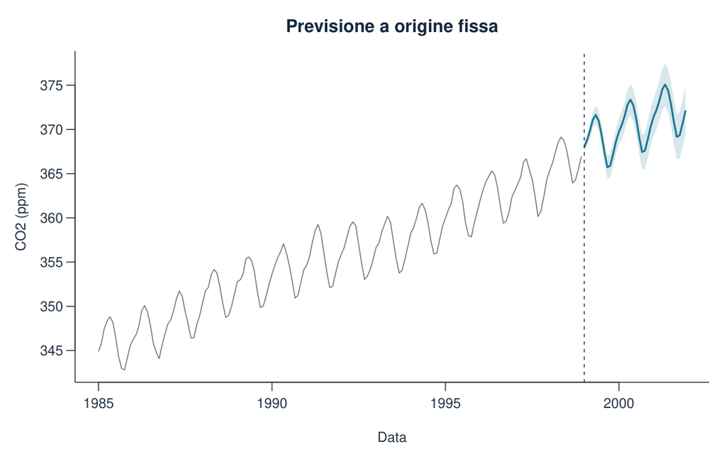

Figura 1 · Output del blocco `passo_03`. PDF vettoriale.

```r
stile_grafico()
plot(c2$dati$data[1:168],as.numeric(train),type="l",col="grey45",
  xlim=range(c2$dati$data),ylim=range(train,previsione$inferiore95,previsione$superiore95),
  xlab="Data",ylab="CO2 (ppm)",main="Previsione a origine fissa")
polygon(c(previsione$data,rev(previsione$data)),
  c(previsione$inferiore95,rev(previsione$superiore95)),
  col=adjustcolor(palette_geo[1],.18),border=NA)
lines(previsione$data,previsione$media,col=palette_geo[1],lwd=2)
abline(v=as.numeric(as.Date("1999-01-01")),lty=2)
```

**Lettura del risultato.** La previsione riguarda l’archivio storico e non la CO₂ attuale. Un cambiamento strutturale futuro non è automaticamente rappresentato da queste bande.

## Variante svolta

**Dal 95% all’80%.** Calcolare l’ampiezza nominale all’80% alle stesse date.

Codice R · variante

```r
previsione$ampiezza80 <- 2*qnorm(.9)*previsione$se
previsione[c(1,12,36),c("h","ampiezza80","ampiezza95")]
stopifnot(all(previsione$ampiezza80<=previsione$ampiezza95))
```

Output eseguito

```
    h ampiezza80 ampiezza95
1   1   0.771216    1.17947
12 12   1.880402    2.87583
36 36   3.534353    5.40533
```

Un livello nominale più basso restringe la fascia senza migliorare il modello. Copertura e ampiezza vanno valutate congiuntamente.

## Errore da riconoscere

Presentare l’intervallo come garanzia universale, o interpretarlo come intervallo di confidenza di una costante senza distinguere il valore futuro.

## Risposta alla domanda

La fascia descrive l’incertezza predittiva condizionale del modello gaussiano stimato. Non comprende automaticamente stima dei parametri, scelta del modello, cambiamenti di regime o copertura simultanea della traiettoria.

## Riferimento nel corso

Questo svolgimento sviluppa il laboratorio `M10_N06` di [GeoStat Lab M10](https://marzione00.github.io/Lab_Geo/#indice). Il [codice originale del laboratorio](https://github.com/marzione00/Lab_Geo/blob/649f7cc577b96bd1044d81e78a2f530813e4f96b/materiali/laboratori/M10/M10_N06.R) è conservato anche in `R/Originali_corso`. Gli ampliamenti e le varianti sono identificati nella mappa allegata.

Documentazione dei metodi: [R stats, arima](https://stat.ethz.ch/R-manual/R-devel/library/stats/html/arima.html), [predict.Arima](https://stat.ethz.ch/R-manual/R-devel/library/stats/html/predict.arima.html), [Box.test](https://stat.ethz.ch/R-manual/R-devel/library/stats/html/box.test.html) e [p.adjust](https://stat.ethz.ch/R-manual/R-devel/library/stats/html/p.adjust.html).